# Mummichog Report: data_pos_both_before_blank_subtraction

mummichog version: 2.2.0-20200207, using metabolic model MFN_1.10.4.

## User input data

User supplied 14391 features as reference list.We are using 2299 features (p < 0.050000) as significant list. The feature level data are shown in the Manhattan plots below.

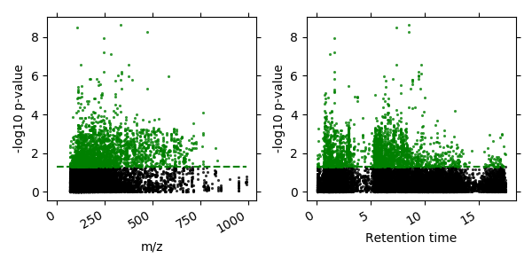

## Top pathways

The reference feature list is mapped to 970 EmpiricalCompounds, significant features to 330 EmpiricalCompounds. In the table below, pathway_size is number of detected EmpiricalCompounds for each pathway; overlap_size is number of significant EmpiricalCompounds. Empirical p-values are estimated by permutation test. Details on EmpiricalCompounds are in 'tables/ListOfEmpiricalCompounds.tsv'.

| Pathways | overlap_size | pathway_size | p-value | overlap_EmpiricalCompounds |
| --- | --- | --- | --- | --- |
| Glutathione Metabolism | 23 | 43 | 0.00294 | E113,E757,E1026,E147,E175,E748,E1586,E1127,E2089,E1338,E1886,E903,E1738,E749,E861,E1286,E1671,E1091,E775,E270,E1227,E24,E1852 |
| Drug metabolism - cytochrome P450 | 9 | 13 | 0.00546 | E2017,E624,E1874,E76,E2125,E960,E857,E256,E311 |
| Putative anti-Inflammatory metabolites formation from EPA | 8 | 12 | 0.01294 | E748,E775,E270,E1127,E529,E757,E861,E1852 |
| Butanoate metabolism | 22 | 46 | 0.02235 | E1605,E957,E667,E188,E687,E1877,E1127,E1479,E26,E397,E655,E654,E885,E1976,E1122,E861,E2059,E13,E1396,E1244,E450,E1641 |
| Leukotriene metabolism | 15 | 29 | 0.02328 | E748,E1414,E775,E1575,E660,E293,E1852,E962,E529,E757,E171,E48,E270,E1539,E982 |
| Aspartate and asparagine metabolism | 58 | 142 | 0.02521 | E2086,E861,E1026,E1990,E2028,E874,E446,E509,E827,E757,E577,E1743,E1994,E450,E1877,E101,E1586,E175,E2057,E1127,E1375,E2089,E1135,E1486,E903,E1671,E858,E1286,E1977,E1182,E26,E38,E1260,E1998,E1227,E654,E… |
| Glutamate metabolism | 19 | 40 | 0.03008 | E748,E388,E113,E1297,E775,E654,E1127,E1122,E1338,E270,E460,E757,E861,E147,E450,E26,E407,E1852,E2059 |

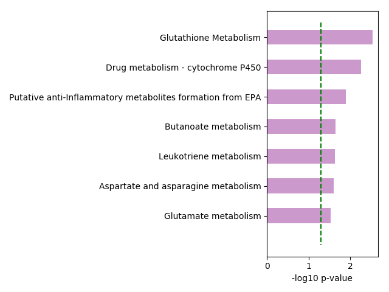

## Top modules

Network modules may capture concerted metabolite activities that are missed by predefined pathways. Use pull-down menus to visualize modules and the activity network, which tries to combine the results of pathway/module analyses. The visualization requires interenet connection.

Showing Node size Visual style

module_1, p=0.01016, 6 metabolites

Benzo[a]pyrene-7,8-oxide; Benzo[a]pyrene-7,8-epoxide, trans-1,2-Dihydrobenzene-1,2-diol, 1,2-Dihydronaphthalene-1,2-diol, Catechol; 1,2-Benzenediol; o-Benzenediol; 1,2-Dihydroxybenzene; Brenzcatechin; Pyrocatechol, (+)-(1R,2R)-1,2-Diphenylethane-1,2-diol, cis-Stilbene oxide

## EmpiricalCompounds favored by above analyses

An EmpiricalCompound is a computational unit for a tentative metabolite. It can group multiple ions, and be any of the isobaric/isomeric species. This table contains EmpiricalCompounds prioritized by pathway/module analysis.

| EmpiricalCompound | Input m/z | Retention time | ion | mz_diff | Statistic | Significant |
| --- | --- | --- | --- | --- | --- | --- |
| E1297 | Best guess: C03564, 1-Pyrroline-2-carboxylate |  | C03912, C03564 |  |  |  |
|  | 114.055633457 | 17.1505984848 | M+H[1+] | 0.0007 | -4.07 | yes |
| E982 | Best guess: CE5139, 12-oxo-20-dihydroxy-leukotriene B4 |  | CE5139 |  |  |  |
|  | 366.203446524 | 5.40301929825 | M+H[1+] | -0.0002 | -3.49 | yes |
|  | 367.204114633 | 5.41020104167 | M(C13)+H[1+] | -0.003 | -2.38 | yes |
| E649 | Best guess: C04221, trans-1,2-Dihydrobenzene-1,2-diol |  | C04221 |  |  |  |
|  | 113.060164475 | 6.47523787879 | M+H[1+] | 0.0005 | 1.64 | no |
|  | 113.060168656 | 6.17396969697 | M+H[1+] | 0.0005 | 2.27 | yes |
| E171 | Best guess: C00302, DL-Glutamate |  | C00302 |  |  |  |
|  | 148.060498297 | 0.827882575758 | M+H[1+] | 0.0 | 5.15 | yes |
|  | 170.042565622 | 1.1515 | M+Na[1+] | 0.0001 | -0.9 | no |
| E188 | Best guess: C06010, (S)-2-Acetolactate |  | C00900, C06010 |  |  |  |
|  | 133.049784039 | 5.45047 | M+H[1+] | 0.0002 | -1.85 | no |
|  | 133.049776141 | 5.58420238095 | M+H[1+] | 0.0002 | 2.79 | yes |
|  | 155.031658742 | 4.56720079365 | M+Na[1+] | 0.0001 | 2.13 | no |
|  | 133.049799201 | 5.38899666667 | M+H[1+] | 0.0002 | 0.97 | no |
| E1877 | Best guess: C00989, 4-Hydroxybutanoic acid |  | C05984, C01188, C01089, C06001, C03197, C00989 |  |  |  |
|  | 127.037752819 | 2.20737348485 | M+Na[1+] | 0.0012 | -2.96 | yes |
|  | 105.055139734 | 2.41831354167 | M+H[1+] | 0.0006 | -3.12 | yes |
| E1338 | Best guess: C00099, beta-Alanine |  | C00213, C00133, C00041, C00099 |  |  |  |
|  | 90.0556585601 | 17.0258636364 | M+H[1+] | 0.0007 | -0.82 | no |
|  | 112.037498497 | 15.876719697 | M+Na[1+] | 0.0005 | 2.01 | no |
|  | 112.037511597 | 16.8540227273 | M+Na[1+] | 0.0005 | -0.33 | no |
|  | 90.0557348629 | 16.7589090909 | M+H[1+] | 0.0008 | -2.17 | yes |
|  | 90.055730976 | 16.3953007576 | M+H[1+] | 0.0008 | -1.98 | no |
|  | 90.0557380106 | 16.0004537879 | M+H[1+] | 0.0008 | -2.29 | yes |
|  | 112.037514646 | 16.2503333333 | M+Na[1+] | 0.0005 | -1.14 | no |
|  | 112.037578282 | 16.5879409091 | M+Na[1+] | 0.0006 | -0.21 | no |
|  | 112.037546053 | 16.7425681818 | M+Na[1+] | 0.0006 | 0.26 | no |
|  | 90.055721581 | 16.8343636364 | M+H[1+] | 0.0007 | -1.59 | no |

[output cut: 595 more lines]

## More data

Full data tables from pathway analysis, module analysis and activity network are stored in the 'tables/' directory. The tsv files can be imported into a spreadsheet program, e.g. MS Excel. Under the 'figures/network_modules/' directory are files intended for Cytoscape (cytoscape.org) visualization. Please refer to Cytoscape's guides for details. Details of this run are recorded in file mummichog.log.txt.